# Affinity Pitch (Thermodynamic Binding)

12/29/2018

## Motivation

The concept of molecular binding is key to pharmaceutical science and has led to the development of modern drugs. By using small molecules to target and bind specific bio-molecules we can alter biological activity. To understand binding, students must gain a quantitative sense of binding strength (affinity).

In the subsequent slides I will outline what binding is, give some examples of binding, and end with a pitch for my shiny app.

## Background

Here are a few diagrams and equations we often use to describe binding reactions:

\(X + Y \rightleftharpoons XY\), where X and Y are molecules that can bind and form the complex 'XY'. The back and forth arrows indicate that the reaction is reversible.

\(K_a = \frac{[XY]}{[X]*[Y]}\), where \(K_a\) is the affinity constant that dictates the ratio between bound and unbound molecular species. The square brackets denote concentration in Molar units of the respective molecular species.

\(Fraction_{XY} = \frac{[X]*K_a}{1+[X]*K_a}\) This fraction bound equation allows us to predict the percent of drug-bound molecules if we know \(K_a\) and the dose of drug. (Assumes a very low concentration of Y)

## Examples of Binding

In my shiny app, a user is able to interactively control \(K_a\) and immediately gain a sense of how it controls binding. Here, I give a still image to for comparison.

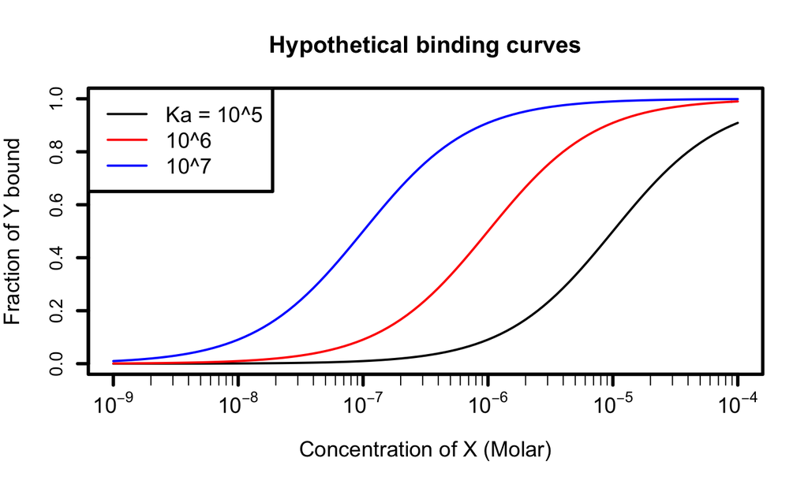

## Conclusion

Interactive learning is a growing field and the shiny app that I am pitching allows users to readily slide a \(K_a\) value around and gain an intuitive sense of how \(K_a\) affects binding—something that a static plot does in only a passive manner.

The app itself is the simplest representation of binding and many more modes could be added. I left them out for simplicity, they include:

- An enzyme binding either inhibitor or substrate
- Multiple binding partners
- Self versus non-self binding